# 05_points_on_cbrtx

## 05_points_on_cbrtx

#### Question

1. Consider the $y=\sqrt[3]{x}$ curve shown below (the cube root function). There are 6 points along the curve, find the missing coordinates of those points in the table.

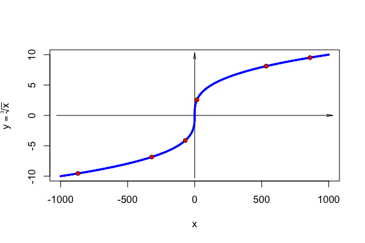

   | $x$ | $y=\sqrt[3]{x}$ |
   | --- | --- |
   | -871 |  |
   |  | -6.85 |
   | -70 |  |
   |  | 2.57 |
   | 533 |  |
   |  | 9.51 |

#### Solution

#### Question

2. Consider the $y=\sqrt[3]{x}$ curve shown below (the cube root function). There are 6 points along the curve, find the missing coordinates of those points in the table.

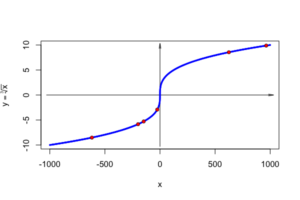

   | $x$ | $y=\sqrt[3]{x}$ |
   | --- | --- |
   | -618 |  |
   |  | -5.84 |
   | -148 |  |
   |  | -2.92 |
   | 625 |  |
   |  | 9.88 |

#### Solution

#### Question

3. Consider the $y=\sqrt[3]{x}$ curve shown below (the cube root function). There are 6 points along the curve, find the missing coordinates of those points in the table.

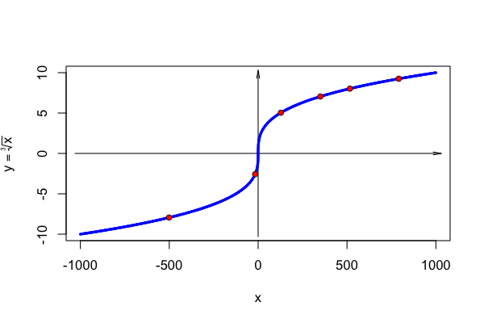

   | $x$ | $y=\sqrt[3]{x}$ |
   | --- | --- |
   | -501 |  |
   |  | -2.57 |
   | 128 |  |
   |  | 7.05 |
   | 516 |  |
   |  | 9.25 |

#### Solution

#### Question

4. Consider the $y=\sqrt[3]{x}$ curve shown below (the cube root function). There are 6 points along the curve, find the missing coordinates of those points in the table.

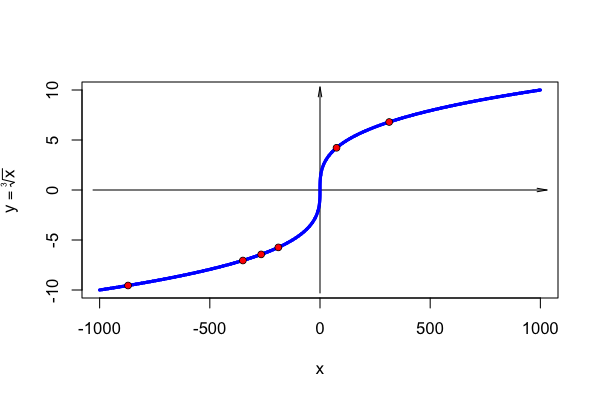

   | $x$ | $y=\sqrt[3]{x}$ |
   | --- | --- |
   | -871 |  |
   |  | -7.05 |
   | -267 |  |
   |  | -5.74 |
   | 75 |  |
   |  | 6.8 |

#### Solution

#### Question

5. Consider the $y=\sqrt[3]{x}$ curve shown below (the cube root function). There are 6 points along the curve, find the missing coordinates of those points in the table.

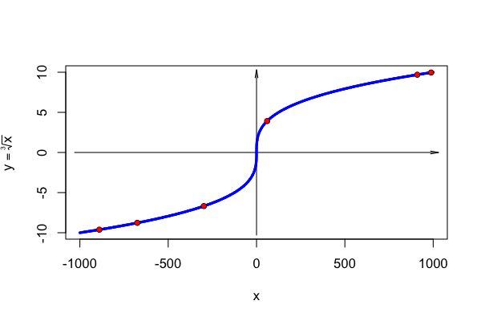

   | $x$ | $y=\sqrt[3]{x}$ |
   | --- | --- |
   | -890 |  |
   |  | -8.77 |
   | -298 |  |
   |  | 3.91 |
   | 910 |  |
   |  | 9.96 |

#### Solution

#### Question

6. Consider the $y=\sqrt[3]{x}$ curve shown below (the cube root function). There are 6 points along the curve, find the missing coordinates of those points in the table.

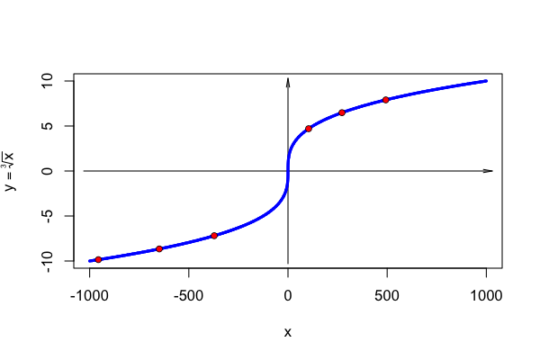

   | $x$ | $y=\sqrt[3]{x}$ |
   | --- | --- |
   | -956 |  |
   |  | -8.66 |
   | -372 |  |
   |  | 4.7 |
   | 272 |  |
   |  | 7.9 |

#### Solution

#### Question

7. Consider the $y=\sqrt[3]{x}$ curve shown below (the cube root function). There are 6 points along the curve, find the missing coordinates of those points in the table.

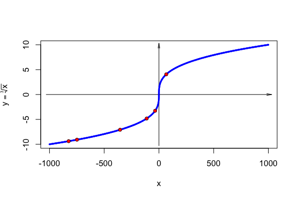

   | $x$ | $y=\sqrt[3]{x}$ |
   | --- | --- |
   | -825 |  |
   |  | -9.08 |
   | -355 |  |
   |  | -4.82 |
   | -35 |  |
   |  | 4.06 |

#### Solution

#### Question

8. Consider the $y=\sqrt[3]{x}$ curve shown below (the cube root function). There are 6 points along the curve, find the missing coordinates of those points in the table.

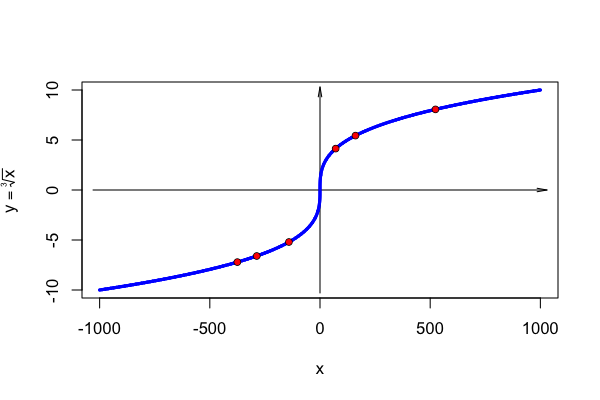

   | $x$ | $y=\sqrt[3]{x}$ |
   | --- | --- |
   | -375 |  |
   |  | -6.6 |
   | -141 |  |
   |  | 4.14 |
   | 161 |  |
   |  | 8.06 |

#### Solution